# PSON Cell Line Data Exploration

## Summary

Exploring the relationship bewteen + **motility** (speed, total distance, and end-to-end distance) across 7 experimental conditions; and + **expression** (TPM normalized RNA-seq read counts) across the same 7 experimental conditions for **9** cell lines.

### Key

Some abbreviations I use in variable names throughout.

- `pson`: all relevant PS-ON cell lines
- `brca`: breast cancer only
- `motil`: motility
- `diag`: diagnosis
- `dist`: distance
- `expr`: expression
- `tpm`: transcripts per million
- `logtpm`: log(TPM + 1)
- `df`: dataframe
- `mat`: matrix

## Setup

Load packages, log into Synapse, etc.

```r
# for getting data from Synapse
library(synapser)
# general data management and manipulation packages
library(tidyverse)
library(stringr)
library(janitor)
library(forcats)
# plotting and visualization packages
library(ggthemes)
library(ggrepel)
library(ggExtra)
library(patchwork)
library(kableExtra)
# analysis packages
library(broom)
library(annotables)
```

```r
synLogin()
```

```
Welcome, James Eddy!NULL
```

## Data collection

All data was retrievied from the [**PS-ON Cell Line Characterization Portal**](https://www.synapse.org/#!Synapse:syn7248578) in Synapse.

### Expression data

I’ll first grab basic “sample” info for cell lines from the [**Proteomics and RNA** Synapse table](https://www.synapse.org/#!Synapse:syn10320914/tables/), for all files containing RSEM gene quantification outputs.

```r
# collect "sample" metadata for cell lines with expression data available
prot_rna_meta_fv_id <- "syn10320914"
sample_df <- synTableQuery(
  str_glue(
    "SELECT replace(name, '_rsem.genes.results.txt', '') as sample, id,
     diagnosis, cellType, catalogNumber, cellLine,
     experimentalCondition, organ, tumorType
     FROM {fv_id}
     WHERE study = 'RNA Study' AND name LIKE '%rsem%'",
    fv_id = prot_rna_meta_fv_id
  ),
  includeRowIdAndRowVersion = FALSE
) %>%
  as.data.frame()
```

```
Waiting for the table index to become available... [--------------------]0.00%   0/100
Waiting for the table index to become available... [--------------------]0.00%   0/100
Waiting for the table index to become available... [####################]100.00%   100/100   Done...
Downloading  [####################]100.00%   8.4kB/8.4kB (1.5MB/s) Job-61384374239763764875351988.csv Done...
```

Taking a look at `sample_df`:

```r
sample_df
```

| sample | id | diagnosis | cellType | catalogNumber | cellLine | experimentalCondition | organ | tumorType |
| --- | --- | --- | --- | --- | --- | --- | --- | --- |
| mRNA_R17 | syn11510905 | Colon Cancer | epithelial | NCI-PBCF-CCL227 | SW620 | Glass | colon | Adenocarcinoma |
| mRNA_R21 | syn11510915 | Colon Cancer | epithelial | NCI-PBCF-CCL227 | SW620 | Hyaluronic Acid Collagen | colon | Adenocarcinoma |
| mRNA_R20 | syn11510925 | Colon Cancer | epithelial | NCI-PBCF-CCL227 | SW620 | Hyaluronic Acid Fibronectin | colon | Adenocarcinoma |
| mRNA_R19 | syn11510935 | Colon Cancer | epithelial | NCI-PBCF-CCL227 | SW620 | 30 kPa polyacrylamide Collagen | colon | Adenocarcinoma |
| mRNA_R18 | syn11510945 | Colon Cancer | epithelial | NCI-PBCF-CCL227 | SW620 | 30 kPa polyacrylamide Fibronectin | colon | Adenocarcinoma |
| mRNA_R16 | syn11510955 | Colon Cancer | epithelial | NCI-PBCF-CCL227 | SW620 | 500 Pa polyacrylamide Collagen | colon | Adenocarcinoma |
| mRNA_R15 | syn11510965 | Colon Cancer | epithelial | NCI-PBCF-CCL227 | SW620 | 500 Pa polyacrylamide Fibronectin | colon | Adenocarcinoma |
| mRNA_R38 | syn11510975 | Colon Cancer | epithelial | NCI-PBCF-CCL228 | SW480 | Glass | colon | Adenocarcinoma |
| mRNA_R42 | syn11510985 | Colon Cancer | epithelial | NCI-PBCF-CCL228 | SW480 | Hyaluronic Acid Collagen | colon | Adenocarcinoma |
| mRNA_R41 | syn11510995 | Colon Cancer | epithelial | NCI-PBCF-CCL228 | SW480 | Hyaluronic Acid Fibronectin | colon | Adenocarcinoma |

[output cut: 53 more lines]

I’ll do a bit of munging with the `experimentalCondition` variable to to create separate variables for `surface`, `laminate`, and `stiffness` (in case we want to break things down further with any visualization or analysis).

```r
sample_tidy_df <- sample_df %>%
  # tidy up experimental condition info
  mutate(experimentalCondition = str_replace_all(
    experimentalCondition, " Acid", "Acid"
  )) %>%
  separate(experimentalCondition,
           into = c("stiffness","stiffness_units", "surface"),
           remove = FALSE, extra = "merge", fill = "left") %>%
  mutate(
    surface = case_when(
      surface %in% c("Collagen", "Fibronectin") ~ experimentalCondition,
      TRUE ~ surface
    ),
    stiffness_units = ifelse(is.na(stiffness), NA, stiffness_units)
  ) %>%
  separate(surface, into = c("surface", "laminate")) %>%
  mutate(
    stiffness = parse_number(stiffness),
    stiffness_units = str_trim(stiffness_units),
    stiffness_norm = case_when(
      stiffness_units == "Pa" ~ stiffness / 1000,
      TRUE ~ stiffness
    )
  )
```

I also split `stiffness_units` into a separate variable and added a `stiffness_norm` such that all values are in “kPa” units. **Note:** scroll over to view the new columns.

```r
sample_tidy_df
```

| sample | id | diagnosis | cellType | catalogNumber | cellLine | experimentalCondition | stiffness | stiffness_units | surface | laminate | organ | tumorType | stiffness_norm |
| --- | --- | --- | --- | --- | --- | --- | --- | --- | --- | --- | --- | --- | --- |
| mRNA_R17 | syn11510905 | Colon Cancer | epithelial | NCI-PBCF-CCL227 | SW620 | Glass | NA | NA | Glass | NA | colon | Adenocarcinoma | NA |
| mRNA_R21 | syn11510915 | Colon Cancer | epithelial | NCI-PBCF-CCL227 | SW620 | HyaluronicAcid Collagen | NA | NA | HyaluronicAcid | Collagen | colon | Adenocarcinoma | NA |
| mRNA_R20 | syn11510925 | Colon Cancer | epithelial | NCI-PBCF-CCL227 | SW620 | HyaluronicAcid Fibronectin | NA | NA | HyaluronicAcid | Fibronectin | colon | Adenocarcinoma | NA |
| mRNA_R19 | syn11510935 | Colon Cancer | epithelial | NCI-PBCF-CCL227 | SW620 | 30 kPa polyacrylamide Collagen | 30 | kPa | polyacrylamide | Collagen | colon | Adenocarcinoma | 30.0 |
| mRNA_R18 | syn11510945 | Colon Cancer | epithelial | NCI-PBCF-CCL227 | SW620 | 30 kPa polyacrylamide Fibronectin | 30 | kPa | polyacrylamide | Fibronectin | colon | Adenocarcinoma | 30.0 |
| mRNA_R16 | syn11510955 | Colon Cancer | epithelial | NCI-PBCF-CCL227 | SW620 | 500 Pa polyacrylamide Collagen | 500 | Pa | polyacrylamide | Collagen | colon | Adenocarcinoma | 0.5 |
| mRNA_R15 | syn11510965 | Colon Cancer | epithelial | NCI-PBCF-CCL227 | SW620 | 500 Pa polyacrylamide Fibronectin | 500 | Pa | polyacrylamide | Fibronectin | colon | Adenocarcinoma | 0.5 |
| mRNA_R38 | syn11510975 | Colon Cancer | epithelial | NCI-PBCF-CCL228 | SW480 | Glass | NA | NA | Glass | NA | colon | Adenocarcinoma | NA |
| mRNA_R42 | syn11510985 | Colon Cancer | epithelial | NCI-PBCF-CCL228 | SW480 | HyaluronicAcid Collagen | NA | NA | HyaluronicAcid | Collagen | colon | Adenocarcinoma | NA |
| mRNA_R41 | syn11510995 | Colon Cancer | epithelial | NCI-PBCF-CCL228 | SW480 | HyaluronicAcid Fibronectin | NA | NA | HyaluronicAcid | Fibronectin | colon | Adenocarcinoma | NA |

[output cut: 53 more lines]

Next, for all the samples in `sample_tidy_df`, I’ll download the file corresponding to the Synapse ID, extract `TPM` values, and combine everything into a single dataframe. Even though I’ll do some additional transformation and filtering with the expression data below, I’ll go ahead and save the full dataframe as `"pson_expr_tpm_df.RData"`.

**Note:** I’ll use the `annotables` package to augment the Ensembl gene IDs with some additional field to provide more context:

- `entrez`: NCBI Entrez gene ID
- `symbol`: HGNC gene symbol
- `biotype`: Protein coding, pseudogene, mitochondrial tRNA, etc.
- `description`: Full gene name/description

I’ll save this dataframe as `"pson_expr_gene_df.RData"`.

```r
# extract expression data from individual files
extract_expr_tpm <- function(syn_id) {
  synGet(syn_id) %>%
    pluck("path") %>%
    read_tsv() %>%
    select(gene_id, TPM)
}
sample_id_map <- sample_tidy_df %>%
  select(sample, id) %>%
  deframe()
pson_expr_tpm_file <- "../data/pson_expr_tpm_df.RData"
if (!fs::file_exists(pson_expr_tpm_file)) {
  # collect expression data for all cell lines and conditions
  pson_expr_tpm_df <- sample_tidy_df %>%
    pluck("id") %>%
    set_names() %>%
    map_df(extract_expr_tpm, .id = "id") %>%
    spread(id, TPM) %>%
    rename(!!!sample_id_map)

  # update/augment gene identifiers; subset to protein coding genes ;
  # remove duplicate IDs
  gene_df <- pson_expr_tpm_df %>%
    select(gene_id) %>%
    left_join(grch37, by = c("gene_id" = "ensgene")) %>%
    filter(biotype == "protein_coding") %>%
    select(gene_id, entrez, symbol, biotype, description) %>%
    filter(!duplicated(entrez) & !duplicated(gene_id))
  # make sure gene info lines up with expression data
  pson_expr_tpm_df <- pson_expr_tpm_df %>%
    left_join(select(gene_df, gene_id), ., by = "gene_id")

  save(pson_expr_tpm_df, file = pson_expr_tpm_file)
  # also save TSV
  write_tsv(pson_expr_tpm_df,
            path = str_replace(pson_expr_tpm_file, "RData", "tsv"))

  save(gene_df, file = "../data/pson_expr_gene_info.RData")
  # also save TSV
  write_tsv(gene_df, path = "../data/pson_expr_gene_info.tsv")
} else {
  load(pson_expr_tpm_file)
  load("../data/pson_expr_gene_info.RData")
}
```

Columns of the `pson_expr_tpm_df` dataframe correspond to `sample` observations in the `sample_tidy_df` dataframe; each row contains the TPM expression value of the gene indicated by the `gene_id` column. Looking at the first few rows only (there are 18682 total…):

```r
head(pson_expr_tpm_df)
```

| gene_id | mRNA_R17 | mRNA_R21 | mRNA_R20 | mRNA_R19 | mRNA_R18 | mRNA_R16 | mRNA_R15 | mRNA_R38 | mRNA_R42 | mRNA_R41 | mRNA_R40 | mRNA_R39 | mRNA_R37 | mRNA_R36 | mRNA_R24 | mRNA_R28 | mRNA_R27 | mRNA_R26 | mRNA_R25 | mRNA_R23 | mRNA_R22 | mRNA_R45 | mRNA_R49 | mRNA_R48 | mRNA_R47 | mRNA_R46 | mRNA_R44 | mRNA_R43 | mRNA_R10 | … |
| --- | --- | --- | --- | --- | --- | --- | --- | --- | --- | --- | --- | --- | --- | --- | --- | --- | --- | --- | --- | --- | --- | --- | --- | --- | --- | --- | --- | --- | --- | --- |
| ENSG00000000003 | 33.56 | 45.10 | 39.42 | 35.61 | 32.10 | 39.49 | 29.90 | 20.80 | 19.63 | 24.60 | 12.37 | 18.25 | 21.11 | 17.54 | 4.95 | 4.01 | 3.61 | 3.61 | 3.45 | 4.35 | 2.98 | 10.35 | 9.95 | 6.47 | 9.83 | 5.07 | 11.59 | 2.96 | 6.22 | … |
| ENSG00000000005 | 0.00 | 0.00 | 0.00 | 0.00 | 0.00 | 0.00 | 0.00 | 0.00 | 0.00 | 0.00 | 0.00 | 0.00 | 0.00 | 0.00 | 0.00 | 0.00 | 0.00 | 0.00 | 0.00 | 0.00 | 0.00 | 0.00 | 0.00 | 0.00 | 0.00 | 0.00 | 0.00 | 0.00 | 0.00 | … |
| ENSG00000000419 | 169.46 | 129.88 | 132.06 | 113.73 | 123.37 | 136.29 | 137.98 | 185.06 | 135.75 | 173.80 | 188.45 | 173.70 | 179.63 | 143.49 | 182.84 | 179.46 | 177.32 | 161.67 | 209.87 | 171.66 | 155.91 | 124.89 | 152.52 | 97.52 | 148.47 | 61.81 | 132.04 | 14.48 | 98.06 | … |
| ENSG00000000457 | 1.85 | 1.85 | 1.77 | 1.93 | 2.30 | 1.54 | 2.00 | 1.75 | 1.41 | 1.76 | 0.84 | 1.54 | 2.35 | 1.83 | 3.49 | 3.81 | 4.87 | 5.07 | 3.90 | 2.99 | 4.27 | 5.14 | 4.29 | 2.12 | 5.34 | 1.28 | 8.40 | 0.45 | 4.46 | … |
| ENSG00000000460 | 5.73 | 11.85 | 10.16 | 9.28 | 10.01 | 8.93 | 7.47 | 7.92 | 5.50 | 8.55 | 4.33 | 5.73 | 5.16 | 7.34 | 6.03 | 6.40 | 7.31 | 11.12 | 5.64 | 6.01 | 6.16 | 14.63 | 11.95 | 9.32 | 10.10 | 9.42 | 9.22 | 6.05 | 8.48 | … |
| ENSG00000000938 | 0.01 | 0.00 | 0.00 | 0.02 | 0.01 | 0.01 | 0.00 | 0.05 | 0.06 | 0.17 | 0.04 | 0.04 | 0.08 | 0.06 | 0.44 | 0.74 | 0.69 | 0.00 | 0.55 | 0.02 | 0.41 | 0.01 | 0.01 | 0.09 | 0.02 | 0.00 | 0.03 | 0.00 | 0.07 | … |

Taking a look at the first few rows of `gene_df`:

```r
head(gene_df)
```

| gene_id | entrez | symbol | biotype | description |
| --- | --- | --- | --- | --- |
| ENSG00000000003 | 7105 | TSPAN6 | protein_coding | tetraspanin 6 [Source:HGNC Symbol;Acc:11858] |
| ENSG00000000005 | 64102 | TNMD | protein_coding | tenomodulin [Source:HGNC Symbol;Acc:17757] |
| ENSG00000000419 | 8813 | DPM1 | protein_coding | dolichyl-phosphate mannosyltransferase polypeptide 1, catalytic subunit [Source:HGNC Symbol;Acc:3005] |
| ENSG00000000457 | 57147 | SCYL3 | protein_coding | SCY1-like 3 (S. cerevisiae) [Source:HGNC Symbol;Acc:19285] |
| ENSG00000000460 | 55732 | C1orf112 | protein_coding | chromosome 1 open reading frame 112 [Source:HGNC Symbol;Acc:25565] |
| ENSG00000000938 | 2268 | FGR | protein_coding | feline Gardner-Rasheed sarcoma viral oncogene homolog [Source:HGNC Symbol;Acc:3697] |

### Motility data

I’ll collect metadata for motility summary files from the [**Physical Characterization View** Synapse table](https://www.synapse.org/#!Synapse:syn7747734/tables/) (again, for all cell lines). I only need the `id`, `catalogNumber`, and `experimentalCondition` columns so that I (i) can download each file below and (ii) correctly match up sample information from the expression data.

```r
# retrieve cell line motility metadata from Synapse file view
motil_meta_fv_id <- "syn7747734"
pson_motil_meta_df <- synTableQuery(
  str_glue("SELECT id, catalogNumber, experimentalCondition FROM {fv_id}
            WHERE study = 'Motility' AND name LIKE '%summary%'",
           fv_id = motil_meta_fv_id),
  includeRowIdAndRowVersion = FALSE
) %>%
  as.data.frame() %>%
  # format experimental condition to match sample dataframe above
  mutate(experimentalCondition = str_replace_all(
    experimentalCondition, " Acid", "Acid"
  ))
```

```
 [####################]100.00%   1/1   Done...
Downloading  [####################]100.00%   12.6kB/12.6kB (163.6kB/s) Job-61384386757129459534949655.csv Done...
```

Here’s what the metadata dataframe looks like (**note:** only 9 of the 29 cell lines have corresponding expression data for the motility conditions tested).

```r
pson_motil_meta_df
```

| id | catalogNumber | experimentalCondition |
| --- | --- | --- |
| syn7576029 | NCI-PBCF-1000 | 30 kPa polyacrylamide Collagen |
| syn7576049 | NCI-PBCF-1000 | 30 kPa polyacrylamide Fibronectin |
| syn7576070 | NCI-PBCF-1000 | 500 Pa polyacrylamide Collagen |
| syn7576093 | NCI-PBCF-1000 | 500 Pa polyacrylamide Fibronectin |
| syn7576124 | NCI-PBCF-1000 | Glass |
| syn7576155 | NCI-PBCF-1000 | HyaluronicAcid Collagen |
| syn7576184 | NCI-PBCF-1000 | HyaluronicAcid Fibronectin |
| syn7576227 | NCI-PBCF-CCL227 | 30 kPa polyacrylamide Collagen |
| syn7576236 | NCI-PBCF-CCL227 | 30 kPa polyacrylamide Fibronectin |
| syn7576247 | NCI-PBCF-CCL227 | 500 Pa polyacrylamide Collagen |

[output cut: 204 more lines]

> **Aside:** format and save sample data

I’ll go ahead and add Synapse IDs for the motility summary files to `sample_tidy_df`. The resulting `sample_map_df` dataframe contains all sample information and file IDs for both expression and motility files (`id_expr` and `id_motil`, respectively). I’ll also create a color palette that I can use for indicating diagnosis (cancer type) in plots below. I’ll save both the `sample_map_df` dataframe and `diagnosis_colors` list as `"pson_sample_map_and_colors.RData"`.

```r
# build and save master sample dataframe
sample_map_df <- sample_tidy_df %>%
  left_join(pson_motil_meta_df,
            by = c("catalogNumber", "experimentalCondition"),
            suffix = c("_expr", "_motil"))
diagnosis_colors <- sample_map_df %>%
  distinct(diagnosis) %>%
  mutate(color = ggthemes::tableau_color_pal("colorblind10")(nrow(.))) %>%
  deframe()
save(sample_map_df, diagnosis_colors,
     file = "../data/pson_sample_map_and_colors.RData")
# also save TSV
write_tsv(sample_map_df, path = "../data/pson_sample_map_df.tsv")
write_tsv(enframe(diagnosis_colors),
          path = "../data/pson_diagnosis_colors_df.tsv")
```

Here’s what the final sample info dataframe looks like:

```r
sample_map_df
```

| sample | id_expr | diagnosis | cellType | catalogNumber | cellLine | experimentalCondition | stiffness | stiffness_units | surface | laminate | organ | tumorType | stiffness_norm | id_motil |
| --- | --- | --- | --- | --- | --- | --- | --- | --- | --- | --- | --- | --- | --- | --- |
| mRNA_R17 | syn11510905 | Colon Cancer | epithelial | NCI-PBCF-CCL227 | SW620 | Glass | NA | NA | Glass | NA | colon | Adenocarcinoma | NA | syn7576272 |
| mRNA_R21 | syn11510915 | Colon Cancer | epithelial | NCI-PBCF-CCL227 | SW620 | HyaluronicAcid Collagen | NA | NA | HyaluronicAcid | Collagen | colon | Adenocarcinoma | NA | syn7576285 |
| mRNA_R20 | syn11510925 | Colon Cancer | epithelial | NCI-PBCF-CCL227 | SW620 | HyaluronicAcid Fibronectin | NA | NA | HyaluronicAcid | Fibronectin | colon | Adenocarcinoma | NA | syn7576312 |
| mRNA_R19 | syn11510935 | Colon Cancer | epithelial | NCI-PBCF-CCL227 | SW620 | 30 kPa polyacrylamide Collagen | 30 | kPa | polyacrylamide | Collagen | colon | Adenocarcinoma | 30.0 | syn7576227 |
| mRNA_R18 | syn11510945 | Colon Cancer | epithelial | NCI-PBCF-CCL227 | SW620 | 30 kPa polyacrylamide Fibronectin | 30 | kPa | polyacrylamide | Fibronectin | colon | Adenocarcinoma | 30.0 | syn7576236 |
| mRNA_R16 | syn11510955 | Colon Cancer | epithelial | NCI-PBCF-CCL227 | SW620 | 500 Pa polyacrylamide Collagen | 500 | Pa | polyacrylamide | Collagen | colon | Adenocarcinoma | 0.5 | syn7576247 |
| mRNA_R15 | syn11510965 | Colon Cancer | epithelial | NCI-PBCF-CCL227 | SW620 | 500 Pa polyacrylamide Fibronectin | 500 | Pa | polyacrylamide | Fibronectin | colon | Adenocarcinoma | 0.5 | syn7576266 |
| mRNA_R38 | syn11510975 | Colon Cancer | epithelial | NCI-PBCF-CCL228 | SW480 | Glass | NA | NA | Glass | NA | colon | Adenocarcinoma | NA | NA |
| mRNA_R42 | syn11510985 | Colon Cancer | epithelial | NCI-PBCF-CCL228 | SW480 | HyaluronicAcid Collagen | NA | NA | HyaluronicAcid | Collagen | colon | Adenocarcinoma | NA | syn7576493 |
| mRNA_R41 | syn11510995 | Colon Cancer | epithelial | NCI-PBCF-CCL228 | SW480 | HyaluronicAcid Fibronectin | NA | NA | HyaluronicAcid | Fibronectin | colon | Adenocarcinoma | NA | syn7576527 |

[output cut: 53 more lines]

And here are our diagnosis colors:

```r
diagnosis_colors
```

```
   Colon Cancer  Not Applicable     Skin Cancer    Brain Cancer Prostate Cancer
      "#006BA4"       "#FF800E"       "#ABABAB"       "#595959"       "#5F9ED1"
  Breast Cancer
      "#C85200"
```

Similar to the expression data above, I’ll download the motility summary files for all cell lines and all experimental conditions, read in the data, format things a bit, and combine into a single dataframe. I’ll save the resulting dataframe as `"pson_motil_summary_df.RData"`. **Note:** I’ll append columns from `sample_map_df` to the motility summary dataframe to avoid additional `join` steps below (the dataframe is still relatively small).

```r
# extract motility summary data from individual files
extract_motil_summary <- function(syn_id) {
  if (!is.na(syn_id)) {
    synGet(syn_id) %>%
      pluck("path") %>%
      # only take the first 4 rows; anything after that is unstructured and might
      # cause errors
      read_tsv(n_max = 4) %>%
      # clean and standardize columns and row names based on readme info
      # ftp://caftpd.nci.nih.gov/psondcc/PhysicalCharacterization/Motility/README.txt
      clean_names() %>%
      mutate(statistic = c(
        "average_value",
        "total_number_of_cells_tracked" ,
        "standard_deviation",
        "standard_error"
      )) %>%
      gather(summary_metric, value, -statistic) %>%
      spread(statistic, value)
  } else {
    data.frame()
  }
}
pson_motil_summary_file <- "../data/pson_motility_summary_df.RData"
if (!fs::file_exists(pson_motil_summary_file)) {
  # collect summary data for all cell lines and conditions
  pson_motil_summary_df <- sample_map_df %>%
    pluck("id_motil") %>%
    set_names() %>%
    map_df(extract_motil_summary, .id = "id_motil") %>%
    left_join(
      sample_map_df,
      by = "id_motil"
    )
  save(pson_motil_summary_df, file = pson_motil_summary_file)
  # also save TSV
  write_tsv(pson_motil_summary_df,
            path = str_replace(pson_motil_summary_file, "RData", "tsv"))
} else {
  load(pson_motil_summary_file)
}
```

## Data formatting

Now that I have the basic information downloaded and stored in relatively usable formats, I’ll do a bit of tidying and minimal “feature engineering” to faciliate visualization and analysis below.

### Expression data

For the expression data, I’ll just convert the dataframe of TPM values into a matrix and save the file to share (providing an alternative format for anyone who wants to use it). I could also normalize the data (i.e., log transform), but I’ll save that for the analysis steps.

#### Save expression matrix file

```r
pson_expr_tpm_mat_file <- "../data/pson_expr_tpm_mat.RData"
if (!fs::file_exists(pson_expr_tpm_mat_file)) {
  pson_expr_tpm_mat <- pson_expr_tpm_df %>%
    column_to_rownames("gene_id") %>%
    as.matrix()
  save(pson_expr_tpm_mat, file = pson_expr_tpm_mat_file)
} else {
  load(pson_expr_tpm_mat_file)
}
```

### Motility data

I happen to know from some earlier inspection of the motility data that scales for average values are fairly different across cell lines. I’ll keep the original values in the dataframe, but add *centered and scaled* versions (using the `scale()` function). I’ll save the augmented dataframe as `"pson_motility_tidy_df.RData"` and use this for analysis below.

```r
scale_this <- function(x) as.vector(scale(x))
pson_motil_tidy_file <- "../data/pson_motility_tidy_df.RData"
if (!fs::file_exists(pson_motil_tidy_file)) {
  # scale and center motility measurement data
  pson_motil_tidy_df <- pson_motil_summary_df %>%
    group_by(cellLine, summary_metric) %>%
    mutate(average_value_scaled = scale_this(average_value)) %>%
    ungroup()
  save(pson_motil_tidy_df, file = pson_motil_tidy_file)
  # also save TSV
  write_tsv(pson_motil_tidy_df,
            path = str_replace(pson_motil_tidy_file, "RData", "tsv"))
} else {
  load(pson_motil_tidy_file)
}
```

## Exploratory data analysis

Checking out trends and distributions for motility and expression data.

### Cell line motility overview

I’ll do a bit of formatting and arranging to control the order in which cell lines and cancer types are plotted (to hopefully make trends easier to see).

```r
# format motility data for plotting (set up factors for axis ordering, etc.)
plot_df <- pson_motil_tidy_df %>%
  group_by(diagnosis, cellLine) %>%
  mutate(
    cv_scaled_value = sd(average_value_scaled) / mean(average_value_scaled)
  ) %>%
  ungroup() %>%
  arrange(desc(cv_scaled_value)) %>%
  replace_na(list(stiffness_norm = "NA", laminate = "NA")) %>%
  mutate(diagnosis = fct_inorder(diagnosis),
         diagnosis = fct_relevel(diagnosis, "Not Applicable", after = Inf)) %>%
  arrange(as.integer(diagnosis)) %>%
  mutate(cellLine = fct_inorder(cellLine))
```

As a quick sanity check, I’ll verify that I can reproduce the plot I previously made in the `motility_brca.R` script:

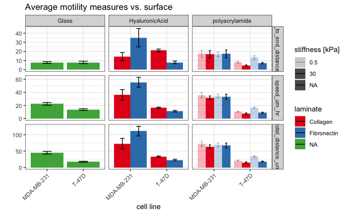

```r
plot_df %>%
  filter(diagnosis %in% c("Breast Cancer")) %>%
  ggplot(aes(x = cellLine, y = average_value)) +
  geom_col(aes(fill = laminate, alpha = stiffness_norm),
           position = position_dodge(0.9)) +
  geom_errorbar(
    aes(ymin = average_value - standard_error,
        ymax = average_value + standard_error,
        color = laminate,
        alpha = stiffness_norm),
    size = 0.5, width = 0.25, position = position_dodge(0.9)
  ) +
  scale_alpha_manual("stiffness [kPa]", values = c(0.3, 1, 1)) +
  scale_color_manual(values = c("black", "black", "black")) +
  scale_fill_brewer(palette = "Set1") +
  facet_grid(summary_metric ~ surface, scales = "free_y") +
  labs(title = "Average motility measures vs. surface") +
  xlab("cell line") +
  ylab("") +
  theme_bw() +
  theme(axis.text.x = element_text(angle = 45, hjust = 1))
```

#### Average values

While I don’t have a strong justification, I’ve decided up front that I’m not interested in the “end-to-end distance” (`end_to_end_distance_um`) summary measure for motility. With that, I still have **2** summary metrics for **9** cell lines, categorized into **6** diagnoses / cancer types, across **7** conditions. That’s a lot of information to capture in one plot but I’ll try to work with heatmaps. The `patchwork` package comes in handy here for combining panels with different color palettes.

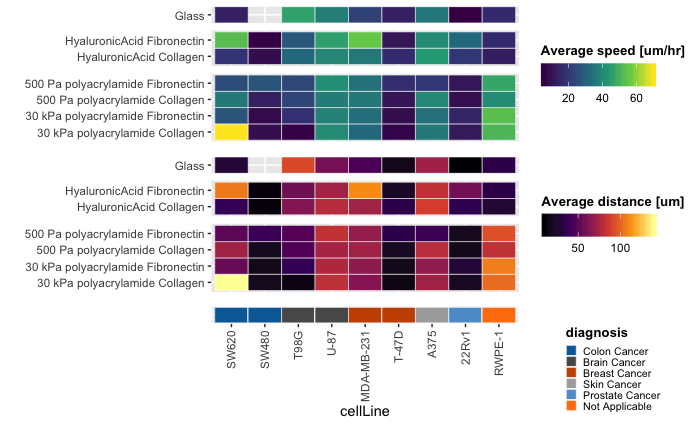

```r
p_speed <- plot_df %>%
  filter(summary_metric == "speed_um_hr") %>%
  ggplot(aes(x = cellLine, y = experimentalCondition)) +
  geom_tile(aes(fill = average_value), colour = "white", size = 0.2) +
  scale_fill_viridis_c("Average speed [um/hr]") +
  guides(fill = guide_colorbar(direction = "horizontal",
                               title.position = "top")) +
  xlab("") +
  ylab("") +
  theme(axis.text.x = element_blank(),
        axis.ticks.x = element_blank(),
        legend.title = element_text(size = 10, face = "bold"),
        strip.text.x = element_blank(),
        strip.text.y = element_blank()) +
  facet_grid(surface ~ summary_metric, scales = "free_y", space = "free_y")
p_dist <- plot_df %>%
  filter(summary_metric == "total_distance_um") %>%
  ggplot(aes(x = cellLine, y = experimentalCondition)) +
  geom_tile(aes(fill = average_value), colour = "white", size = 0.2) +
  scale_fill_viridis_c("Average distance [um]", option = 3) +
  guides(fill = guide_colorbar(direction = "horizontal",
                               title.position = "top")) +
  xlab("") +
  ylab("") +
  theme(axis.text.x = element_blank(),
        axis.ticks.x = element_blank(),
        legend.title = element_text(size = 10, face = "bold"),
        strip.text.x = element_blank(),
        strip.text.y = element_blank(),
        plot.margin = margin(t = -10)) +
  facet_grid(surface ~ summary_metric, scales = "free_y", space = "free_y")
p_diag <- plot_df %>%
  filter(summary_metric == "speed_um_hr") %>%
  ggplot(aes(x = cellLine, y = 1)) +
  geom_tile(aes(fill = diagnosis), colour = "white", size = 0.2) +
  scale_fill_manual(values = diagnosis_colors) +
  ylab("") +
  theme(axis.text.x = element_text(angle = 90, hjust = 1, vjust = 0.5),
        axis.text.y = element_blank(),
        axis.ticks.y = element_blank(),
        legend.margin = margin(t = 80),
        legend.title = element_text(size = 10, face = "bold"),
        legend.key.size = ggplot2::unit(8, "pt"),
        legend.text = element_text(size = 8),
        strip.text.x = element_blank(),
        plot.margin = margin(t = -5, b = 10)) +
  facet_grid(. ~ summary_metric, scales = "free_y", space = "free_y")
p_comb <- p_speed + p_dist + p_diag +
  plot_layout(ncol = 1, heights = c(20, 20, 2.5))
p_comb
```

#### Scaled and centered

As expected, the differing scales of motility metrics across conditions for each cell line make it tough to discern any patterns. I’ll try again with the centered and scaled average values. **Note:** this is admittedly a lot of duplicated code to produce a plot with only minor changes in content.

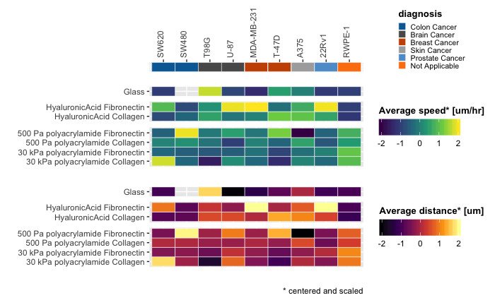

```r
p_diag <- plot_df %>%
  filter(summary_metric == "speed_um_hr") %>%
  ggplot(aes(x = cellLine, y = 1)) +
  geom_tile(aes(fill = diagnosis), colour = "white", size = 0.2) +
  scale_fill_manual(values = diagnosis_colors) +
  scale_x_discrete(position = "top") +
  xlab("") +
  ylab("") +
  theme(axis.text.x = element_text(angle = 90, hjust = 0, vjust = 0.5),
        axis.text.y = element_blank(),
        axis.ticks.y = element_blank(),
        legend.margin = margin(t = -60),
        legend.title = element_text(size = 10, face = "bold"),
        legend.key.size = ggplot2::unit(8, "pt"),
        legend.text = element_text(size = 8),
        strip.text.x = element_blank(),
        plot.margin = margin(t = -5, b = 10)) +
  facet_grid(. ~ summary_metric, scales = "free_y", space = "free_y")
p_speed <- plot_df %>%
  filter(summary_metric == "speed_um_hr") %>%
  ggplot(aes(x = cellLine, y = experimentalCondition)) +
  geom_tile(aes(fill = average_value_scaled), colour = "white", size = 0.2) +
  scale_fill_viridis_c("Average speed* [um/hr]") +
  guides(fill = guide_colorbar(direction = "horizontal",
                               title.position = "top")) +
  xlab("") +
  ylab("") +
  theme(axis.text.x = element_blank(),
        axis.ticks.x = element_blank(),
        legend.title = element_text(size = 10, face = "bold"),
        strip.text.x = element_blank(),
        strip.text.y = element_blank()) +
  facet_grid(surface ~ summary_metric, scales = "free_y", space = "free_y")
p_dist <- plot_df %>%
  filter(summary_metric == "total_distance_um") %>%
  ggplot(aes(x = cellLine, y = experimentalCondition)) +
  geom_tile(aes(fill = average_value_scaled), colour = "white", size = 0.2) +
  scale_fill_viridis_c("Average distance* [um]", option = 3) +
  guides(fill = guide_colorbar(direction = "horizontal",
                               title.position = "top")) +
  xlab("") +
  ylab("") +
  theme(axis.text.x = element_blank(),
        axis.ticks.x = element_blank(),
        legend.title = element_text(size = 10, face = "bold"),
        strip.text.x = element_blank(),
        strip.text.y = element_blank(),
        plot.margin = margin(b = 10)) +
  facet_grid(surface ~ summary_metric, scales = "free_y", space = "free_y")
p_comb <- p_diag + p_speed + p_dist +
  plot_layout(ncol = 1, heights = c(2.5, 20, 20)) +
  labs(caption = "* centered and scaled")
p_comb
```

Still nothing as obvious or pronounced as I might have hoped. For example, none of the conditions seem to be universally associated with increased (or decreased) motility relative to the others — even “glass” is the lowest value for some cell lines and the highest for others. I guess the takeaway is that motility regulation and response is cell-type specific — though there might be common drivers on the molecular level.

#### Motility vs. condition

Here’s a different way to look at possible trends of cell line motility with respect to experimental condition:

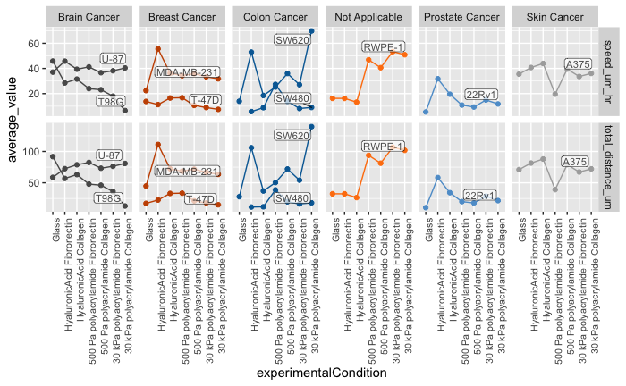

```r
pson_motil_tidy_df %>%
  filter(summary_metric != "end_to_end_distance_um") %>%
  mutate(experimentalCondition = fct_rev(experimentalCondition),
         experimentalCondition = fct_relevel(experimentalCondition, "Glass")) %>%
  ggplot(aes(x = experimentalCondition, y = average_value)) +
  geom_point(aes(colour = diagnosis)) +
  geom_line(aes(colour = diagnosis, group = cellLine)) +
  ggrepel::geom_label_repel(
    data = pson_motil_tidy_df %>%
      filter(experimentalCondition == "30 kPa polyacrylamide Collagen",
             summary_metric != "end_to_end_distance_um"),
    aes(label = cellLine),
    size = 3, nudge_y = 5, alpha = 0.7, label.padding = unit(0.1, "lines")
  ) +
  scale_colour_manual(values = diagnosis_colors) +
  guides(colour = FALSE) +
  facet_grid(summary_metric ~ diagnosis, scales = "free") +
  theme(axis.text.x = element_text(angle = 90, hjust = 1, size = 8))
```

#### Distributions

This is a quick check to see how motility metric values are distributed across conditions for each cell line. I’m looking for some semblance of normality, though the sample size is fairly small. I’ll likely check associations with both parameteric and non-parametric methods below, just to be safe.

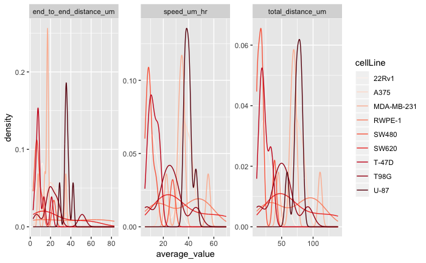

```r
pson_motil_tidy_df %>%
  ggplot(aes(x = average_value)) +
  stat_density(aes(colour = cellLine),
               geom = "line", position = "identity") +
  scale_color_brewer(palette = "Reds") +
  facet_wrap(~ summary_metric, scales = "free")
```

### Expression overview

Before analyzing the expression data, I’d like to apply some basic transformations: log-normalizing the TPM expression values and removing/filtering low or rarely expressed genes.

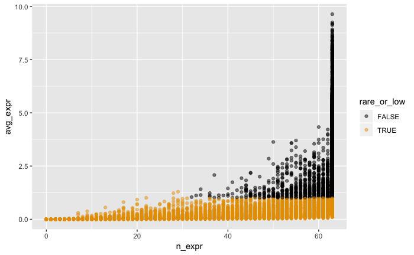

```r
expr_filter_df <- pson_expr_tpm_df %>%
  gather(sample, tpm, -gene_id) %>%
  mutate(log_tpm = log(tpm + 1)) %>%
  group_by(gene_id) %>%
  summarize(n_expr = sum(log_tpm > 0),
            avg_expr = mean(log_tpm),
            # formula for ~CV for log-normalized data, according to Wikipedia
            cv_expr = sqrt(exp(sd(log_tpm) ^ 2) - 1)) %>%
  ungroup() %>%
  mutate(rare = n_expr < max(n_expr) / 2,
         low = avg_expr < 1,
         rare_or_low = rare | low)
expr_filter_df %>%
  ggplot(aes(x = n_expr, y = avg_expr)) +
  geom_point(aes(colour = rare_or_low), alpha = 0.5) +
  scale_color_colorblind()
```

**Note:** I’ll write a simple function for this step, so I can apply the same filtering for subsets of the data.

```r
log_and_filter_genes <- function(expr_tpm_melted_df) {
  keep_genes <- expr_tpm_melted_df %>%
    mutate(log_tpm = log(tpm + 1)) %>%
    group_by(gene_id) %>%
    summarize(n_expr = sum(log_tpm > 0),
              avg_expr = mean(log_tpm),
              # formula for ~CV for log-normalized data, according to Wikipedia
              cv_expr = sqrt(exp(sd(log_tpm) ^ 2) - 1)) %>%
    ungroup() %>%
    mutate(rare = n_expr < max(n_expr) / 2,
           low = avg_expr < 1,
           rare_or_low = rare | low) %>%
    filter(!rare_or_low) %>%
    pluck("gene_id")

    expr_tpm_melted_df %>%
      filter(gene_id %in% keep_genes) %>%
      mutate(logtpm = log(tpm + 1))
}
```

```r
pson_expr_logtpm_df <- pson_expr_tpm_df %>%
  gather(sample, tpm, -gene_id) %>%
  log_and_filter_genes()
```

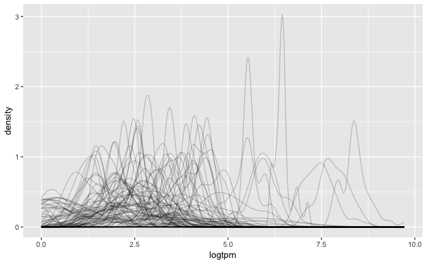

```r
set.seed(0)
pson_expr_logtpm_df %>%
  group_by(gene_id) %>%
  nest() %>%
  sample_n(100) %>%
  unnest() %>%
  ggplot(aes(x = logtpm)) +
  stat_density(aes(group = gene_id),
               geom = "line", position = "identity", alpha = 0.2)
```

Looks like a bunch of Guassian-ish curves to me, so that’s encouraging.

## Motility-expression correlation

Below, I’ll take a look at correlation between gene expression and motility metrics in PS-ON cell lines from a few different perspectives:

1. Across all cell lines and cancer types (diagnoses)
2. Across all cell lines within each cancer type
3. Across each breast cancer cell line

### Across all cell lines

To ease some of the operations below, I’ll build a nested dataframe where, for each gene and summary metric, the `data` column stores a dataframe with expression values and average motility values across all cell lines and conditions.

```r
nest_expr_motil_data <- function(expr_logtpm_df, facet = NULL) {
  groupvars <- c("gene_id", "summary_metric")
  joinvars <- c("sample")
  if (!is.null(facet)) {
    groupvars <- c(groupvars, facet)
    joinvars <- c(joinvars, facet)
  } else {
    facet <- ""
  }
  expr_logtpm_df %>%
    left_join(
      pson_motil_tidy_df %>%
        filter(!(summary_metric %in% "end_to_end_distance_um")) %>%
        select(sample, experimentalCondition, one_of(facet),
               summary_metric, average_value_scaled),
      by = joinvars
    ) %>%
    filter(!is.na(experimentalCondition)) %>%
    select(gene_id, logtpm, summary_metric, average_value_scaled,
           experimentalCondition, one_of(facet)) %>%
    group_by(.dots = groupvars) %>%
    nest() %>%
    ungroup()
}
# build master dataframe for inspecting expression ~ motility trends
pson_expr_motil_df <- nest_expr_motil_data(pson_expr_logtpm_df)
```

```
Unknown columns: ``Unknown columns: ``
```

Using the `pson_expr_motil_df` “master” dataframe, I can iterate across all genes to compute the correlation between expression and motility values across conditions. To clarify what this looks like for a single gene:

```r
p1 <- pson_expr_motil_df %>%
  slice(1) %>%
  unnest(data) %>%
  ggplot(aes(x = logtpm, y = average_value_scaled)) +
  geom_point() +
  geom_smooth(method = "lm") +
  ylab("speed_um_hr")
p1 <- ggMarginal(p1)
```

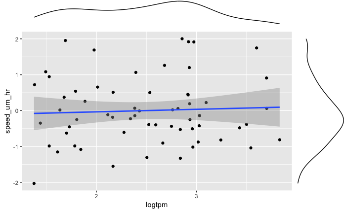

```r
grid::grid.newpage()
grid::grid.draw(p1)
```

```r
calc_genewise_corr <- function(expr_motil_df) {
  expr_motil_corr_df <- expr_motil_df %>%
    mutate(
      pearson = map(
        data,
        ~ cor.test(.$logtpm, .$average_value_scaled,
                   method = "pearson") %>%
          tidy() %>%
          dplyr::rename_all(.funs = ~str_c("pearson_", .))
      ),
      spearman = map(
        data,
        ~ cor.test(.$logtpm, .$average_value_scaled,
                   method = "spearman", exact = FALSE) %>%
          tidy() %>%
          dplyr::rename_all(.funs = ~str_c("spearman_", .))
      )
    ) %>%
    select(-data)

  groupvars <- setdiff(
    names(expr_motil_corr_df),
    c("gene_id", "pearson", "spearman")
  )
  print(groupvars)
  # # unnest and adjust for multiple testing
  expr_motil_corr_df %>%
    unnest(pearson) %>%
    unnest(spearman) %>%
    group_by(.dots = groupvars) %>%
    mutate_at(.vars = vars(matches(".*_p.value")),
              .funs = funs(adj = p.adjust(., method = "BH"))) %>%
    ungroup()
}
# compute correlation across cell lines and conditions for all genes
expr_motil_corr_all_df <- calc_genewise_corr(pson_expr_motil_df)
```

```
[1] "summary_metric"
```

Ideally, I’d like to find genes that are significantly correlated with motility after correcting for multiple hypothesis testing (i.e., Benjamini-Hochberg). Filtering for genes with adjusted p-value < 0.05, I get…

```r
expr_motil_corr_all_df
```

| gene_id | summary_metric | pearson_estimate | pearson_statistic | pearson_p.value | pearson_parameter | pearson_conf.low | pearson_conf.high | pearson_method | pearson_alternative | spearman_estimate | spearman_statistic | spearman_p.value | spearman_method | spearman_alternative | pearson_p.value_adj | spearman_p.value_adj |
| --- | --- | --- | --- | --- | --- | --- | --- | --- | --- | --- | --- | --- | --- | --- | --- | --- |
| ENSG00000000003 | speed_um_hr | 5.045637e-02 | 0.3913317977 | 0.69693830 | 60 | -0.201855700 | 0.29648811 | Pearson's product-moment correlation | two.sided | 9.972174e-03 | 39315.00 | 0.93868331 | Spearman's rank correlation rho | two.sided | 0.9998495 | 0.9999342 |
| ENSG00000000003 | total_distance_um | 3.590632e-02 | 0.2783086221 | 0.78173234 | 60 | -0.215797208 | 0.28313529 | Pearson's product-moment correlation | two.sided | -1.964216e-03 | 39789.00 | 0.98791131 | Spearman's rank correlation rho | two.sided | 0.9999672 | 0.9999342 |
| ENSG00000000419 | speed_um_hr | 1.912371e-01 | 1.5091697200 | 0.13650374 | 60 | -0.061467064 | 0.42090100 | Pearson's product-moment correlation | two.sided | 4.515122e-02 | 37918.00 | 0.72749202 | Spearman's rank correlation rho | two.sided | 0.9998495 | 0.9999342 |
| ENSG00000000419 | total_distance_um | 1.932406e-01 | 1.5255906256 | 0.13236619 | 60 | -0.059394273 | 0.42261133 | Pearson's product-moment correlation | two.sided | 6.982952e-02 | 36938.00 | 0.58967471 | Spearman's rank correlation rho | two.sided | 0.9999672 | 0.9999342 |
| ENSG00000000457 | speed_um_hr | 9.544346e-02 | 0.7426923626 | 0.46056590 | 60 | -0.158093493 | 0.33717386 | Pearson's product-moment correlation | two.sided | 1.000013e-01 | 35739.85 | 0.43932858 | Spearman's rank correlation rho | two.sided | 0.9998495 | 0.9999342 |
| ENSG00000000457 | total_distance_um | 9.576424e-02 | 0.7452115920 | 0.45905313 | 60 | -0.157777826 | 0.33746077 | Pearson's product-moment correlation | two.sided | 8.297763e-02 | 36415.88 | 0.52140771 | Spearman's rank correlation rho | two.sided | 0.9999672 | 0.9999342 |
| ENSG00000000460 | speed_um_hr | 1.335095e-01 | 1.0435019445 | 0.30090210 | 60 | -0.120269267 | 0.37090919 | Pearson's product-moment correlation | two.sided | 1.481239e-01 | 33828.85 | 0.25057903 | Spearman's rank correlation rho | two.sided | 0.9998495 | 0.9999342 |
| ENSG00000000460 | total_distance_um | 9.604621e-02 | 0.7474261914 | 0.45772565 | 60 | -0.157500313 | 0.33771292 | Pearson's product-moment correlation | two.sided | 7.776379e-02 | 36622.92 | 0.54799829 | Spearman's rank correlation rho | two.sided | 0.9999672 | 0.9999342 |
| ENSG00000001036 | speed_um_hr | 3.867586e-02 | 0.2998062344 | 0.76536116 | 60 | -0.213151385 | 0.28568435 | Pearson's product-moment correlation | two.sided | -8.838972e-02 | 43221.04 | 0.49450803 | Spearman's rank correlation rho | two.sided | 0.9998495 | 0.9999342 |
| ENSG00000001036 | total_distance_um | 3.605997e-02 | 0.2795011000 | 0.78082155 | 60 | -0.215650519 | 0.28327680 | Pearson's product-moment correlation | two.sided | -7.385956e-02 | 42644.04 | 0.56832821 | Spearman's rank correlation rho | two.sided | 0.9999672 | 0.9999342 |

[output cut: 990 more lines]

```r
expr_motil_corr_all_sig_df <- expr_motil_corr_all_df %>%
  filter_at(.vars = vars(matches(".*_p.value_adj")),
            .vars_predicate = any_vars(. < 0.05))
expr_motil_corr_all_sig_df
```

| gene_id | summary_metric | pearson_estimate | pearson_statistic | pearson_p.value | pearson_parameter | pearson_conf.low | pearson_conf.high | pearson_method | pearson_alternative | spearman_estimate | spearman_statistic | spearman_p.value | spearman_method | spearman_alternative | pearson_p.value_adj | spearman_p.value_adj |
| --- | --- | --- | --- | --- | --- | --- | --- | --- | --- | --- | --- | --- | --- | --- | --- | --- |

…nothing significant. Let’s try to look at unadjusted p-values.

```r
expr_motil_corr_all_sig_df <- expr_motil_corr_all_df %>%
  filter_at(.vars = vars(matches(".*_p.value")),
            .vars_predicate = any_vars(. < 0.05)) %>%
  select(gene_id, summary_metric,
         pearson = pearson_estimate, spearman = spearman_estimate) %>%
  gather(corr_type, corr, pearson, spearman) %>%
  left_join(select(gene_df, gene_name = symbol, everything()), by = "gene_id")
expr_motil_corr_all_sig_df
```

| gene_id | summary_metric | corr_type | corr | gene_name | entrez | biotype | description |
| --- | --- | --- | --- | --- | --- | --- | --- |
| ENSG00000005302 | speed_um_hr | pearson | 0.26563650 | MSL3 | 10943 | protein_coding | male-specific lethal 3 homolog (Drosophila) [Source:HGNC Symbol;Acc:7370] |
| ENSG00000005302 | total_distance_um | pearson | 0.25686862 | MSL3 | 10943 | protein_coding | male-specific lethal 3 homolog (Drosophila) [Source:HGNC Symbol;Acc:7370] |
| ENSG00000037757 | speed_um_hr | pearson | 0.25628864 | MRI1 | 84245 | protein_coding | methylthioribose-1-phosphate isomerase 1 [Source:HGNC Symbol;Acc:28469] |
| ENSG00000059588 | speed_um_hr | pearson | 0.31184567 | TARBP1 | 6894 | protein_coding | TAR (HIV-1) RNA binding protein 1 [Source:HGNC Symbol;Acc:11568] |
| ENSG00000059588 | total_distance_um | pearson | 0.31841657 | TARBP1 | 6894 | protein_coding | TAR (HIV-1) RNA binding protein 1 [Source:HGNC Symbol;Acc:11568] |
| ENSG00000068784 | total_distance_um | pearson | 0.25525119 | SRBD1 | 55133 | protein_coding | S1 RNA binding domain 1 [Source:HGNC Symbol;Acc:25521] |
| ENSG00000079785 | speed_um_hr | pearson | 0.25496369 | DDX1 | 1653 | protein_coding | DEAD (Asp-Glu-Ala-Asp) box helicase 1 [Source:HGNC Symbol;Acc:2734] |
| ENSG00000079785 | total_distance_um | pearson | 0.27046988 | DDX1 | 1653 | protein_coding | DEAD (Asp-Glu-Ala-Asp) box helicase 1 [Source:HGNC Symbol;Acc:2734] |
| ENSG00000091651 | speed_um_hr | pearson | 0.28044400 | ORC6 | 23594 | protein_coding | origin recognition complex, subunit 6 [Source:HGNC Symbol;Acc:17151] |
| ENSG00000091651 | total_distance_um | pearson | 0.26402888 | ORC6 | 23594 | protein_coding | origin recognition complex, subunit 6 [Source:HGNC Symbol;Acc:17151] |

[output cut: 190 more lines]

With this view, we still get 68 genes that are correlated with *either* speed or distance based on *either* Pearson or Spearman correlation. Taking a look at these genes:

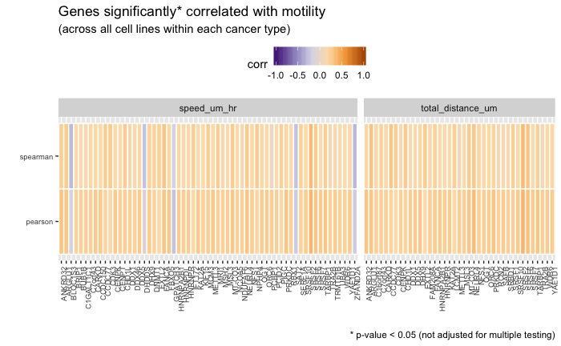

```r
expr_motil_corr_all_sig_df %>%
  ggplot(aes(x = gene_name, y = corr_type)) +
  geom_tile(aes(fill = corr), colour = "white", size = 0.5) +
  scale_fill_distiller(palette = "PuOr", limits = c(-1, 1)) +
  ylab("") +
  xlab("") +
  facet_grid( ~ summary_metric,
             scales = "free_x", space = "free_x", drop = TRUE) +
  theme(axis.text.x = element_text(angle = 90, hjust = 1, size = 7),
        axis.text.y = element_text(size = 7),
        legend.position = "top",
        strip.text.y = element_text(angle = 0, size = 6)) +
  labs(title = "Genes significantly* correlated with motility",
       subtitle = "(across all cell lines within each cancer type)",
       caption = "* p-value < 0.05 (not adjusted for multiple testing)")
```

### For each cancer type

Taking a slightly more granular approach, I’ll look at gene-motility correlation across cell lines for each cancer type.

```r
# build master dataframe for inspecting expression ~ motility trends
pson_expr_motil_diag_df <- pson_expr_tpm_df %>%
  gather(sample, tpm, -gene_id) %>%
  left_join(select(sample_map_df, sample, diagnosis), by = "sample") %>%
  group_by(diagnosis) %>%
  nest() %>%
  mutate(data = map(data, log_and_filter_genes)) %>%
  unnest(data) %>%
  nest_expr_motil_data(facet = "diagnosis")
```

The principle here is pretty much the same, but with fewer points in each of the distributions that I’m comparing (at the same time, there’s less noise due to cell type specific effects, so we can generally expect to see correlation values with greater magnitude.)

```r
p2 <- pson_expr_motil_diag_df %>%
  slice(1) %>%
  unnest(data) %>%
  ggplot(aes(x = logtpm, y = average_value_scaled)) +
  geom_point() +
  geom_smooth(method = "lm") +
  ylab("speed_um_hr")
p2 <- ggMarginal(p2)
```

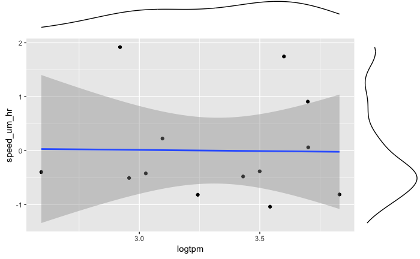

```r
grid::grid.newpage()
grid::grid.draw(p2)
```

```r
# compute correlation across cell lines and conditions for all genes and all
# cancer types
expr_motil_corr_diag_df <- calc_genewise_corr(pson_expr_motil_diag_df)
```

```
[1] "summary_metric" "diagnosis"
```

Now, genes that are significantly correlated with motility after correcting for multiple hypothesis testing (i.e., BH-adjusted p-value):

```r
expr_motil_corr_diag_sig_df <- expr_motil_corr_diag_df %>%
  filter_at(.vars = vars(matches(".*_p.value_adj")),
            .vars_predicate = any_vars(. < 0.05)) %>%
  select(gene_id, summary_metric, diagnosis,
         pearson = pearson_estimate, spearman = spearman_estimate) %>%
  gather(corr_type, corr, pearson, spearman) %>%
  left_join(select(gene_df, gene_name = symbol, everything()), by = "gene_id")
expr_motil_corr_diag_sig_df
```

| gene_id | summary_metric | diagnosis | corr_type | corr | gene_name | entrez | biotype | description |
| --- | --- | --- | --- | --- | --- | --- | --- | --- |
| ENSG00000121578 | speed_um_hr | Not Applicable | pearson | 0.8731941 | B4GALT4 | 8702 | protein_coding | UDP-Gal:betaGlcNAc beta 1,4- galactosyltransferase, polypeptide 4 [Source:HGNC Symbol;Acc:927] |
| ENSG00000121578 | total_distance_um | Not Applicable | pearson | 0.8731941 | B4GALT4 | 8702 | protein_coding | UDP-Gal:betaGlcNAc beta 1,4- galactosyltransferase, polypeptide 4 [Source:HGNC Symbol;Acc:927] |
| ENSG00000068078 | speed_um_hr | Skin Cancer | pearson | 0.7483752 | FGFR3 | 2261 | protein_coding | fibroblast growth factor receptor 3 [Source:HGNC Symbol;Acc:3690] |
| ENSG00000068078 | total_distance_um | Skin Cancer | pearson | 0.7483752 | FGFR3 | 2261 | protein_coding | fibroblast growth factor receptor 3 [Source:HGNC Symbol;Acc:3690] |
| ENSG00000101040 | speed_um_hr | Skin Cancer | pearson | 0.9383931 | ZMYND8 | 23613 | protein_coding | zinc finger, MYND-type containing 8 [Source:HGNC Symbol;Acc:9397] |
| ENSG00000101040 | total_distance_um | Skin Cancer | pearson | 0.9383931 | ZMYND8 | 23613 | protein_coding | zinc finger, MYND-type containing 8 [Source:HGNC Symbol;Acc:9397] |
| ENSG00000113734 | speed_um_hr | Skin Cancer | pearson | 0.9706464 | BNIP1 | 662 | protein_coding | BCL2/adenovirus E1B 19kDa interacting protein 1 [Source:HGNC Symbol;Acc:1082] |
| ENSG00000113734 | total_distance_um | Skin Cancer | pearson | 0.9706464 | BNIP1 | 662 | protein_coding | BCL2/adenovirus E1B 19kDa interacting protein 1 [Source:HGNC Symbol;Acc:1082] |
| ENSG00000151552 | speed_um_hr | Skin Cancer | pearson | 0.9897275 | QDPR | 5860 | protein_coding | quinoid dihydropteridine reductase [Source:HGNC Symbol;Acc:9752] |
| ENSG00000151552 | total_distance_um | Skin Cancer | pearson | 0.9897275 | QDPR | 5860 | protein_coding | quinoid dihydropteridine reductase [Source:HGNC Symbol;Acc:9752] |

[output cut: 26 more lines]

An impressive 9 gene(s) correlated with *either* speed or distance based on *either* Pearson or Spearman correlation within *any* cancer type.

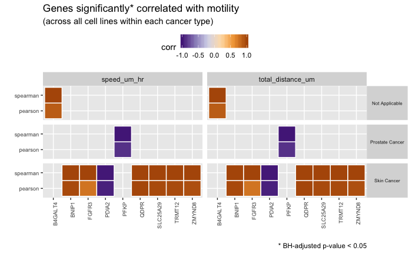

```r
expr_motil_corr_diag_sig_df %>%
  ggplot(aes(x = gene_name, y = corr_type)) +
  geom_tile(aes(fill = corr), colour = "white", size = 0.5) +
  scale_fill_distiller(palette = "PuOr", limits = c(-1, 1)) +
  ylab("") +
  xlab("") +
  facet_grid(diagnosis ~ summary_metric,
             scales = "free_x", space = "free_x", drop = TRUE) +
  theme(axis.text.x = element_text(angle = 90, hjust = 1, size = 7),
        axis.text.y = element_text(size = 7),
        legend.position = "top",
        strip.text.y = element_text(angle = 0, size = 6)) +
  labs(title = "Genes significantly* correlated with motility",
       subtitle = "(across all cell lines within each cancer type)",
       caption = "* BH-adjusted p-value < 0.05")
```

#### Across breast cancer cell lines

These are the same results as above, but focusing in on the genes that appear to be correlated with motility across breast cancer cell lines (and not correcting for multiple testing).

```r
expr_motil_corr_diag_brca_sig_df <- expr_motil_corr_diag_df %>%
  filter(diagnosis == "Breast Cancer") %>%
  filter_at(.vars = vars(matches(".*_p.value")),
            .vars_predicate = any_vars(. < 0.01)) %>%
  select(gene_id, summary_metric, diagnosis,
         pearson = pearson_estimate, spearman = spearman_estimate) %>%
  gather(corr_type, corr, pearson, spearman) %>%
  left_join(select(gene_df, gene_name = symbol, everything()), by = "gene_id")
expr_motil_corr_diag_brca_sig_df
```

| gene_id | summary_metric | diagnosis | corr_type | corr | gene_name | entrez | biotype | description |
| --- | --- | --- | --- | --- | --- | --- | --- | --- |
| ENSG00000105227 | speed_um_hr | Breast Cancer | pearson | 0.6192188 | PRX | 57716 | protein_coding | periaxin [Source:HGNC Symbol;Acc:13797] |
| ENSG00000105227 | total_distance_um | Breast Cancer | pearson | 0.5518474 | PRX | 57716 | protein_coding | periaxin [Source:HGNC Symbol;Acc:13797] |
| ENSG00000105287 | total_distance_um | Breast Cancer | pearson | 0.6111050 | PRKD2 | 25865 | protein_coding | protein kinase D2 [Source:HGNC Symbol;Acc:17293] |
| ENSG00000117877 | speed_um_hr | Breast Cancer | pearson | -0.6692733 | CD3EAP | 10849 | protein_coding | CD3e molecule, epsilon associated protein [Source:HGNC Symbol;Acc:24219] |
| ENSG00000128973 | speed_um_hr | Breast Cancer | pearson | -0.7183920 | CLN6 | 54982 | protein_coding | ceroid-lipofuscinosis, neuronal 6, late infantile, variant [Source:HGNC Symbol;Acc:2077] |
| ENSG00000142794 | speed_um_hr | Breast Cancer | pearson | 0.6140656 | NBPF3 | 84224 | protein_coding | neuroblastoma breakpoint family, member 3 [Source:HGNC Symbol;Acc:25076] |
| ENSG00000148688 | speed_um_hr | Breast Cancer | pearson | -0.6833364 | RPP30 | 10556 | protein_coding | ribonuclease P/MRP 30kDa subunit [Source:HGNC Symbol;Acc:17688] |
| ENSG00000160124 | total_distance_um | Breast Cancer | pearson | -0.6638252 | CCDC58 | 131076 | protein_coding | coiled-coil domain containing 58 [Source:HGNC Symbol;Acc:31136] |
| ENSG00000175376 | speed_um_hr | Breast Cancer | pearson | -0.6676741 | EIF1AD | 84285 | protein_coding | eukaryotic translation initiation factor 1A domain containing [Source:HGNC Symbol;Acc:28147] |
| ENSG00000185946 | total_distance_um | Breast Cancer | pearson | 0.6295284 | RNPC3 | 55599 | protein_coding | RNA-binding region (RNP1, RRM) containing 3 [Source:HGNC Symbol;Acc:18666] |

[output cut: 16 more lines]

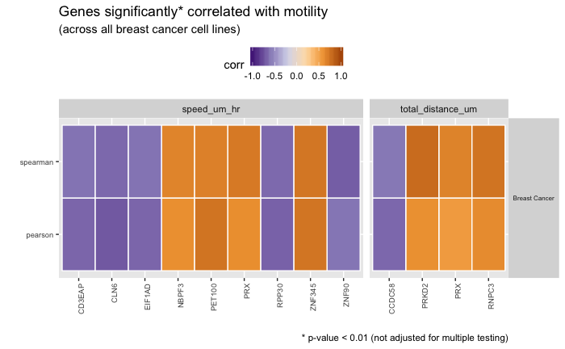

```r
expr_motil_corr_diag_brca_sig_df %>%
  ggplot(aes(x = gene_name, y = corr_type)) +
  geom_tile(aes(fill = corr), colour = "white", size = 0.5) +
  scale_fill_distiller(palette = "PuOr", limits = c(-1, 1)) +
  ylab("") +
  xlab("") +
  facet_grid(diagnosis ~ summary_metric,
             scales = "free_x", space = "free_x", drop = TRUE) +
  theme(axis.text.x = element_text(angle = 90, hjust = 1, size = 7),
        axis.text.y = element_text(size = 7),
        legend.position = "top",
        strip.text.y = element_text(angle = 0, size = 6)) +
  labs(title = "Genes significantly* correlated with motility",
       subtitle = "(across all breast cancer cell lines)",
       caption = "* p-value < 0.01 (not adjusted for multiple testing)")
```

### For each breast cancer cell line

#### Save data for breast cancer cell lines only

While we’re here… I’ll create some new files with just the motility and expression data for breast cancer cell lines in the PS-ON portal.

```r
brca_sample_map_df <- sample_map_df %>%
  filter(diagnosis == "Breast Cancer")
brca_motil_tidy_df <- pson_motil_tidy_df %>%
  filter(diagnosis == "Breast Cancer")
brca_expr_tpm_df <- pson_expr_tpm_df %>%
  select(gene_id, one_of(brca_sample_map_df$sample))
brca_expr_tpm_mat <- brca_expr_tpm_df %>%
    column_to_rownames("gene_id") %>%
    as.matrix()
```

```
Setting row names on a tibble is deprecated.
```

```r
save(brca_sample_map_df, file = "../data/pson_brca_sample_map_df.RData")
write_tsv(brca_sample_map_df, "../data/pson_brca_sample_map_df.tsv")
save(brca_motil_tidy_df, file = "../data/pson_brca_motility_tidy_df.RData")
write_tsv(brca_motil_tidy_df, "../data/pson_brca_motility_tidy_df.tsv")
save(brca_expr_tpm_df, file = "../data/pson_brca_expr_tpm_df.RData")
write_tsv(brca_expr_tpm_df, "../data/pson_brca_expr_tpm_df.tsv")
save(brca_expr_tpm_mat, file = "../data/pson_brca_expr_tpm_mat.RData")
```

```r
brca_expr_motil_cellline_df <- pson_expr_tpm_df %>%
  gather(sample, tpm, -gene_id) %>%
  left_join(select(sample_map_df, sample, diagnosis, cellLine),
            by = "sample") %>%
  filter(diagnosis == "Breast Cancer") %>%
  group_by(cellLine) %>%
  nest() %>%
  mutate(data = map(data, log_and_filter_genes)) %>%
  unnest(data) %>%
  nest_expr_motil_data(facet = "cellLine")
```

Even fewer points in each of the distributions that I’m comparing (**1** per experimental condition in both the motility and expression data) — higher likeliyhood of finding stronger correlation, but definitely less statistical power.

```r
p3 <- brca_expr_motil_cellline_df %>%
  slice(1) %>%
  unnest(data) %>%
  ggplot(aes(x = logtpm, y = average_value_scaled)) +
  geom_point() +
  geom_smooth(method = "lm") +
  ylab("speed_um_hr")
p3 <- ggMarginal(p3)
```

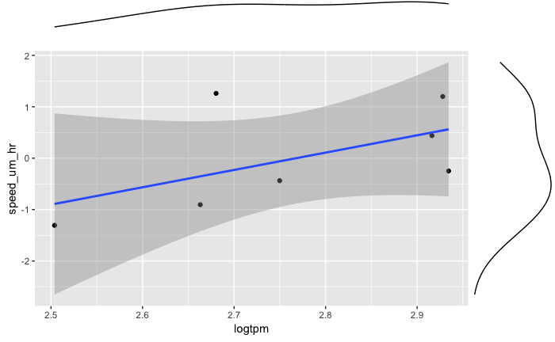

```r
grid::grid.newpage()
grid::grid.draw(p3)
```

```r
# compute correlation across cell lines and conditions for all genes and all
# cancer types
brca_expr_motil_corr_cellline_df <- calc_genewise_corr(brca_expr_motil_cellline_df)
```

```
[1] "summary_metric" "cellLine"
```

Any genes significantly correlated with motility after correcting for multiple hypothesis testing (BH-adjusted p-value)?

```r
brca_expr_motil_corr_cellline_sig_df <- brca_expr_motil_corr_cellline_df %>%
  filter_at(.vars = vars(matches(".*_p.value_adj")),
            .vars_predicate = any_vars(. < 0.05)) %>%
  select(gene_id, summary_metric, cellLine,
         pearson = pearson_estimate, spearman = spearman_estimate) %>%
  gather(corr_type, corr, pearson, spearman) %>%
  left_join(select(gene_df, gene_name = symbol, everything()), by = "gene_id")
brca_expr_motil_corr_cellline_sig_df
```

| gene_id | summary_metric | cellLine | corr_type | corr | gene_name | entrez | biotype | description |
| --- | --- | --- | --- | --- | --- | --- | --- | --- |
| ENSG00000100324 | speed_um_hr | T-47D | pearson | 0.8502771 | TAB1 | 10454 | protein_coding | TGF-beta activated kinase 1/MAP3K7 binding protein 1 [Source:HGNC Symbol;Acc:18157] |
| ENSG00000102886 | speed_um_hr | T-47D | pearson | -0.8265436 | GDPD3 | 79153 | protein_coding | glycerophosphodiester phosphodiesterase domain containing 3 [Source:HGNC Symbol;Acc:28638] |
| ENSG00000100324 | speed_um_hr | T-47D | spearman | 1.0000000 | TAB1 | 10454 | protein_coding | TGF-beta activated kinase 1/MAP3K7 binding protein 1 [Source:HGNC Symbol;Acc:18157] |
| ENSG00000102886 | speed_um_hr | T-47D | spearman | -1.0000000 | GDPD3 | 79153 | protein_coding | glycerophosphodiester phosphodiesterase domain containing 3 [Source:HGNC Symbol;Acc:28638] |

```r
brca_expr_motil_corr_cellline_sig_df <- brca_expr_motil_corr_cellline_df %>%
  filter_at(.vars = vars(matches(".*_p.value")),
            .vars_predicate = any_vars(. < 0.001)) %>%
  select(gene_id, summary_metric, cellLine,
         pearson = pearson_estimate, spearman = spearman_estimate) %>%
  gather(corr_type, corr, pearson, spearman) %>%
  left_join(select(gene_df, gene_name = symbol, everything()), by = "gene_id")
brca_expr_motil_corr_cellline_sig_df
```

| gene_id | summary_metric | cellLine | corr_type | corr | gene_name | entrez | biotype | description |
| --- | --- | --- | --- | --- | --- | --- | --- | --- |
| ENSG00000032444 | total_distance_um | T-47D | pearson | -0.7121374 | PNPLA6 | 10908 | protein_coding | patatin-like phospholipase domain containing 6 [Source:HGNC Symbol;Acc:16268] |
| ENSG00000072062 | speed_um_hr | T-47D | pearson | 0.8848130 | PRKACA | 5566 | protein_coding | protein kinase, cAMP-dependent, catalytic, alpha [Source:HGNC Symbol;Acc:9380] |
| ENSG00000100324 | speed_um_hr | T-47D | pearson | 0.8502771 | TAB1 | 10454 | protein_coding | TGF-beta activated kinase 1/MAP3K7 binding protein 1 [Source:HGNC Symbol;Acc:18157] |
| ENSG00000102886 | speed_um_hr | T-47D | pearson | -0.8265436 | GDPD3 | 79153 | protein_coding | glycerophosphodiester phosphodiesterase domain containing 3 [Source:HGNC Symbol;Acc:28638] |
| ENSG00000103540 | total_distance_um | T-47D | pearson | 0.7963456 | CCP110 | 9738 | protein_coding | centriolar coiled coil protein 110kDa [Source:HGNC Symbol;Acc:24342] |
| ENSG00000105072 | speed_um_hr | T-47D | pearson | -0.9562575 | C19orf44 | 84167 | protein_coding | chromosome 19 open reading frame 44 [Source:HGNC Symbol;Acc:26141] |
| ENSG00000106012 | speed_um_hr | T-47D | pearson | 0.9379490 | IQCE | 23288 | protein_coding | IQ motif containing E [Source:HGNC Symbol;Acc:29171] |
| ENSG00000107890 | speed_um_hr | T-47D | pearson | 0.8768417 | ANKRD26 | 22852 | protein_coding | ankyrin repeat domain 26 [Source:HGNC Symbol;Acc:29186] |
| ENSG00000117862 | speed_um_hr | T-47D | pearson | -0.9453486 | TXNDC12 | 51060 | protein_coding | thioredoxin domain containing 12 (endoplasmic reticulum) [Source:HGNC Symbol;Acc:24626] |
| ENSG00000135093 | total_distance_um | T-47D | pearson | -0.9031975 | USP30 | 84749 | protein_coding | ubiquitin specific peptidase 30 [Source:HGNC Symbol;Acc:20065] |

[output cut: 54 more lines]

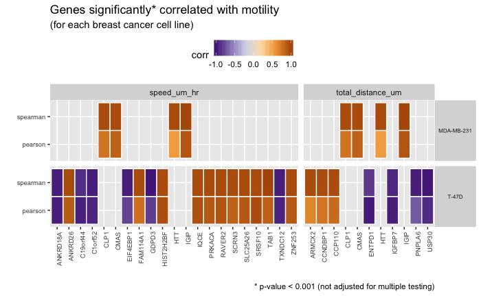

```r
brca_expr_motil_corr_cellline_sig_df %>%
  ggplot(aes(x = gene_name, y = corr_type)) +
  geom_tile(aes(fill = corr), colour = "white", size = 0.5) +
  scale_fill_distiller(palette = "PuOr", limits = c(-1, 1)) +
  ylab("") +
  xlab("") +
  facet_grid(cellLine ~ summary_metric,
             scales = "free_x", space = "free_x", drop = TRUE) +
  theme(axis.text.x = element_text(angle = 90, hjust = 1, size = 7),
        axis.text.y = element_text(size = 7),
        legend.position = "top",
        strip.text.y = element_text(angle = 0, size = 6)) +
  labs(title = "Genes significantly* correlated with motility",
       subtitle = "(for each breast cancer cell line)",
       caption = "* p-value < 0.001 (not adjusted for multiple testing)")
```

Notably, not much overlap (and in some cases contrasting patterns) between the two cell lines.